# Homework2

# Preface

### Exercises

1. We can use the data for prediction without assumptions because in that case we don’t care much about causality. If cigar smoking can predict better health,we don’t care that this is may be because cigar smokers are wealthy people who can afford better treatment.

## Separability

### Exercises

1. The downside in adding interactions is that if we got the interaction wrong we’ll cause overfitting.

## Normal distribution

### Exercises

1. Classical economist’s stories such as consumption that is characterized by different dispersion (variance) as a function of income levels
2. If we understand the structure and effect of the “noise” we can form an opinion of how much trust can be given to the results.

# Data

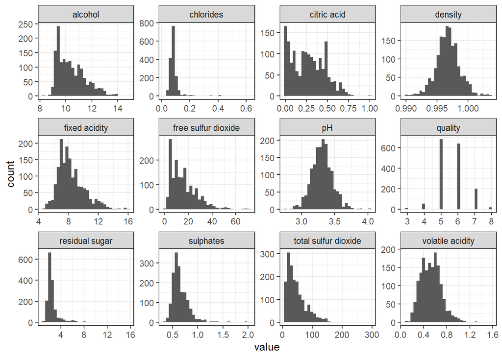

Wine dataset histplot

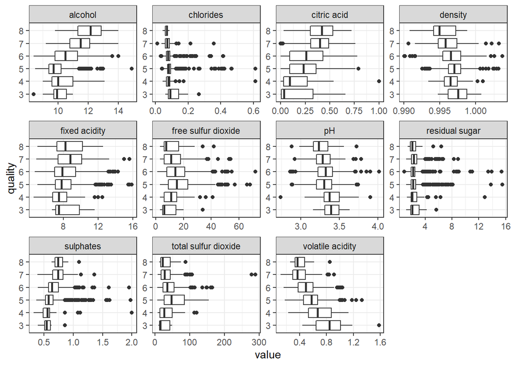

Wine dataset boxplot

# Model

## Linear regression

### Exercises

```
## # A tibble: 12 x 5
##    term                    estimate std.error statistic  p.value
##    <chr>                      <dbl>     <dbl>     <dbl>    <dbl>
##  1 (Intercept)             37.8     26.3          1.44  1.50e- 1
##  2 `fixed acidity`          0.0495   0.0318       1.56  1.20e- 1
##  3 `volatile acidity`      -1.05     0.143       -7.39  2.88e-13
##  4 `citric acid`           -0.170    0.177       -0.960 3.37e- 1
##  5 `residual sugar`         0.0223   0.0183       1.22  2.24e- 1
##  6 chlorides               -1.86     0.516       -3.60  3.29e- 4
##  7 `free sulfur dioxide`    0.00322  0.00263      1.22  2.21e- 1
##  8 `total sulfur dioxide`  -0.00273  0.000876    -3.11  1.90e- 3
##  9 density                -34.4     26.8         -1.29  1.99e- 1
## 10 pH                      -0.246    0.230       -1.07  2.84e- 1
## 11 sulphates                0.846    0.137        6.17  9.42e-10
## 12 alcohol                  0.264    0.0324       8.17  8.42e-16
```

```
## # A tibble: 6 x 1
##   .pred
##   <dbl>
## 1  5.73
## 2  5.33
## 3  5.06
## 4  5.17
## 5  5.30
## 6  5.51
```

```
## # A tibble: 3 x 3
##   .metric .estimator .estimate
##   <chr>   <chr>          <dbl>
## 1 rmse    standard       0.629
## 2 rsq     standard       0.378
## 3 mae     standard       0.491
```

The main difference between confidence intervals and RMSE evaluation is that RMSE doesn’t depended on the assumptions of the underlying DGP.

## Logistic regression

### Exersices

1. Using linear regression for binary outcomes may produce predictions outside of [0,1] boundaries. Another side effect is that creates a heteroscedasticity problem

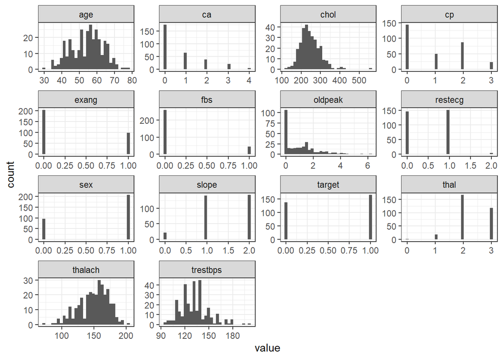

heart dataset histplot

### Linear regression

#### Exercises

```
## # A tibble: 14 x 5
##    term         estimate std.error statistic    p.value
##    <chr>           <dbl>     <dbl>     <dbl>      <dbl>
##  1 (Intercept)  0.819     0.358        2.29  0.0232
##  2 age         -0.00253   0.00332     -0.762 0.447
##  3 sex         -0.166     0.0580      -2.86  0.00471
##  4 cp           0.111     0.0283       3.93  0.000115
##  5 trestbps    -0.00154   0.00149     -1.03  0.304
##  6 chol        -0.000398  0.000488    -0.816 0.416
##  7 fbs         -0.0103    0.0716      -0.144 0.886
##  8 restecg      0.0859    0.0485       1.77  0.0782
##  9 thalach      0.00259   0.00137      1.89  0.0598
## 10 exang       -0.169     0.0646      -2.62  0.00942
## 11 oldpeak     -0.0393    0.0277      -1.42  0.158
## 12 slope        0.0866    0.0512       1.69  0.0926
## 13 ca          -0.121     0.0264      -4.59  0.00000774
## 14 thal        -0.0807    0.0414      -1.95  0.0529
```

```
## [1] -0.2095871  1.1807559
```

We can see that the predictions are indeed outside of [0,1] boundaries.

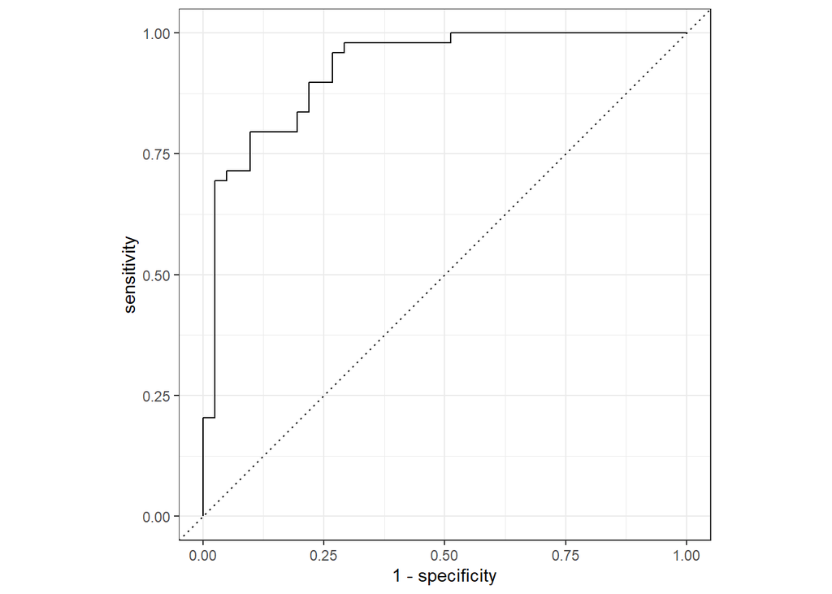

### Logistic regression

#### Exercises

```
## # A tibble: 14 x 5
##    term        estimate std.error statistic   p.value
##    <chr>          <dbl>     <dbl>     <dbl>     <dbl>
##  1 (Intercept)  3.97      3.00        1.32  0.186
##  2 age         -0.0196    0.0281     -0.699 0.485
##  3 sex         -1.36      0.538      -2.53  0.0113
##  4 cp           0.802     0.229       3.51  0.000453
##  5 trestbps    -0.0189    0.0120     -1.57  0.116
##  6 chol        -0.00491   0.00416    -1.18  0.238
##  7 fbs         -0.240     0.596      -0.403 0.687
##  8 restecg      0.700     0.410       1.71  0.0879
##  9 thalach      0.0186    0.0121      1.53  0.126
## 10 exang       -1.10      0.518      -2.13  0.0330
## 11 oldpeak     -0.361     0.255      -1.42  0.157
## 12 slope        0.570     0.414       1.38  0.168
## 13 ca          -0.854     0.217      -3.93  0.0000856
## 14 thal        -0.578     0.329      -1.76  0.0790
```

```
## [1] 0.005262991 0.992216901
```

We can see that the predictions of logistic model are within the [0,1] boundaries.

## Regularization

### Exercises

1. Using an absolute (or squared term) in the penalty is required to ignore the sign of the coefficients. In case the sign is taken into account negative coefficients with be (inappropriately) rewarded.
2. This is a feature of the loss function. Absolute distance that is used in lasso allows for “corner” solutions as opposed to quadratic distance used in ridge

### Exercises

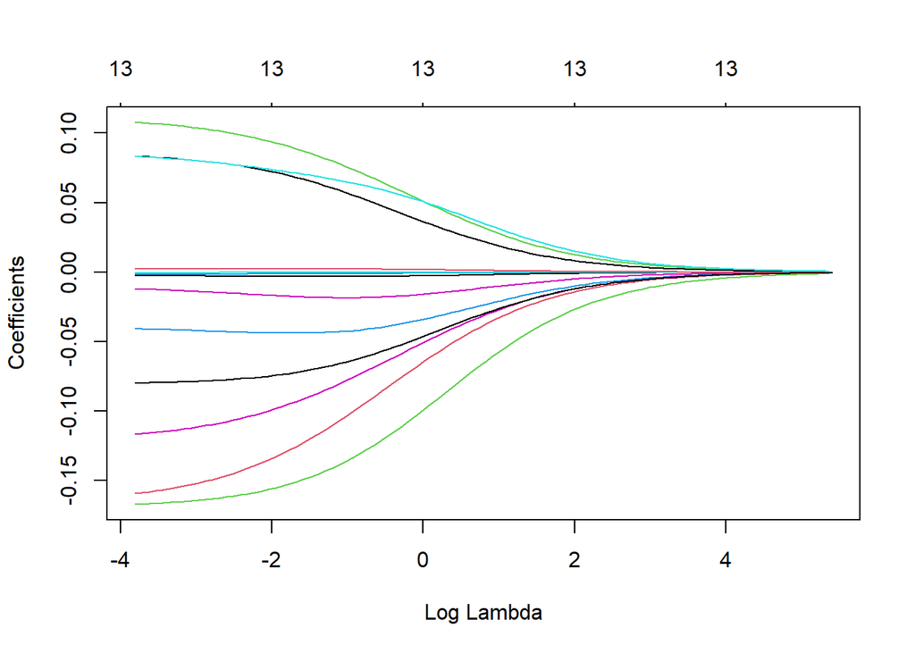

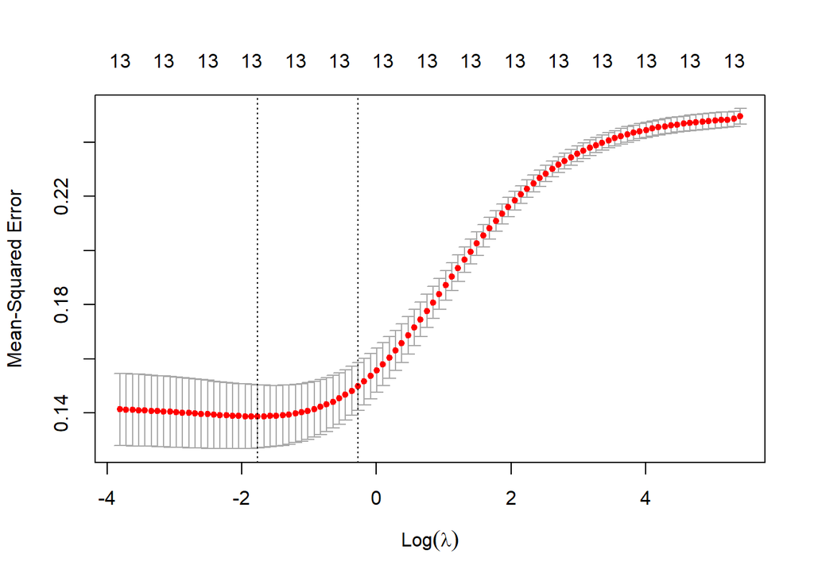

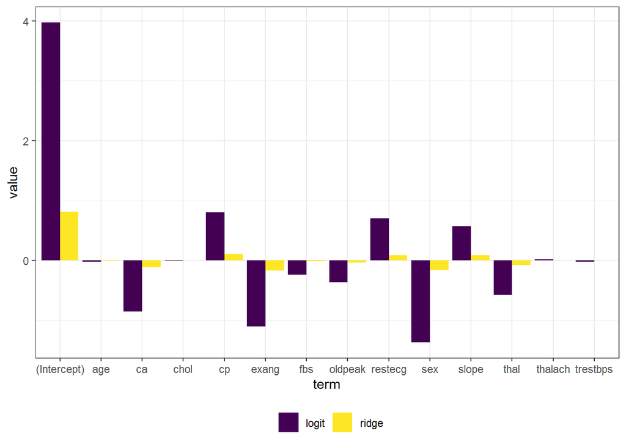

We can see that ridge produces smaller (in absolute value) coeffs.

4. Perhaps the problem is that if we have a covariate that has no effect it suggests that the economic model was misspecified?

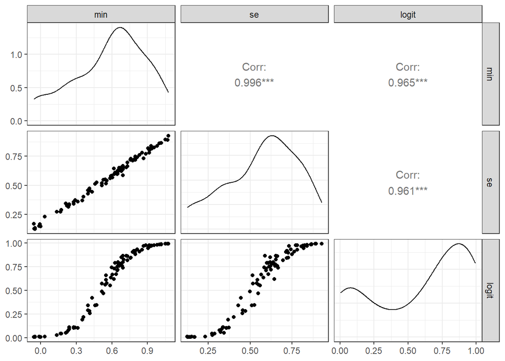

6.

Min lambda conf matrix

```
## Confusion Matrix and Statistics
##
##           Reference
## Prediction  1  0
##          1 48 13
##          0  1 28
##
##                Accuracy : 0.8444
##                  95% CI : (0.7528, 0.9123)
##     No Information Rate : 0.5444
##     P-Value [Acc > NIR] : 1.629e-09
##
##                   Kappa : 0.6787
##
##  Mcnemar's Test P-Value : 0.003283
##
##             Sensitivity : 0.9796
##             Specificity : 0.6829
##          Pos Pred Value : 0.7869
##          Neg Pred Value : 0.9655
##              Prevalence : 0.5444
##          Detection Rate : 0.5333
##    Detection Prevalence : 0.6778
##       Balanced Accuracy : 0.8313
##
##        'Positive' Class : 1
##
```

One se lambda conf matrix

```
## Confusion Matrix and Statistics
##
##           Reference
## Prediction  1  0
##          1 47 15
##          0  2 26
##
##                Accuracy : 0.8111
##                  95% CI : (0.7149, 0.8859)
##     No Information Rate : 0.5444
##     P-Value [Acc > NIR] : 1.061e-07
##
##                   Kappa : 0.6091
##
##  Mcnemar's Test P-Value : 0.003609
##
##             Sensitivity : 0.9592
##             Specificity : 0.6341
##          Pos Pred Value : 0.7581
##          Neg Pred Value : 0.9286
##              Prevalence : 0.5444
##          Detection Rate : 0.5222
##    Detection Prevalence : 0.6889
##       Balanced Accuracy : 0.7967
##
##        'Positive' Class : 1
##
```